# Orientation: L1 vs L2

## Data analysis

We have 152 subjects in total and 2432 observations. The subjects are distributed as follows:

```
Source: local data frame [4 x 3]
Groups: Lang [?]

    Lang   List n_distinct(Subject)
  (fctr) (fctr)               (int)
1     L2      0                  74
2     L2      1                  48
3     L1      0                  13
4     L1      1                  17
```

After removal of entries with missing data due to wrong answers, we have 152 subjects in total and 1993 observations left. The subjects are distributed as follows:

```
Source: local data frame [4 x 3]
Groups: Lang [?]

    Lang   List n_distinct(Subject)
  (fctr) (fctr)               (int)
1     L2      0                  74
2     L2      1                  48
3     L1      0                  13
4     L1      1                  17
```

## Model Building

We set up a categorical variable, `Lang`, to inform about the speakers L1 and L2 and a another categorical variable, `Type`, to inform about the Type of question MATCH and MISMATCH. Each different question is identified by the variable `Trial` that we treat as a categorical variable as well, since we assume no influence of the order in which the question was posed. Finally, we record in the variable `List` the list from which the question is drawn, that is, list A or list B. The response variable is reaction time measured in milliseconds.

We are not intersted in the effect of the specific trials or the specific subjects. However, we are interested in knowing whether these effects are important for the variance of responses. Hence, we specify a mixed effects model with random effects associated to the factors Trial and Subject and fixed effects associated with the other factors. Due to the fact that we split trials between two lists and administered the two lists to different subjects the random effects of Trial and Subject are nested within List. Further, for the way we split trials, Trial is nested also within Type. Within the nesting structure subjects and questions are fully crossed. We fitted our model in R using the package `lme4` [add reference].

The distribution of reaction times is right skewed and never reaches zero. Under these conditions, logarithm transformation or generalized linear mixed models with Gamma family and log link function are common approaches to meet the assumptions underlying mixed linear models. In our case, we found that a log-transformed response variable imporved considerably the diagnostic plots (conditional and marginal residual qqplots) of the selected models. A Gamma family transformation with log link function yield much worse diagnostic plots.

Our starting model is: `lmer(log(Time) ~ Type + List + Lang + (1 | List:Subject) + (1 | List:Type:Trial), data = DLM)`

The random effects are significant. This is also supported by the portion of standard deviation of the residuals that is imputable to the two random effects.

```r
lmm<- lmer(log(Time) ~ Type + Lang + List + (1 | List:Subject)+ (1 | List:Type:Trial), data = DLM, REML=FALSE)
```

### Likelihood ratio

We gain preliminary insight using likelihood ratio tests for main fixed effects:

```r
lmm.0 <- lmer(log(Time) ~ (1 | List:Subject)+ (1 | List:Type:Trial), data = DLM)
lmm.1 <- update(lmm.0, .~. + Type)
anova(lmm.0,lmm.1)
```

```
Data: DLM
Models:
lmm.0: log(Time) ~ (1 | List:Subject) + (1 | List:Type:Trial)
lmm.1: log(Time) ~ (1 | List:Subject) + (1 | List:Type:Trial) + Type
      Df  AIC  BIC logLik deviance Chisq Chi Df Pr(>Chisq)
lmm.0  4 2318 2340  -1155     2310
lmm.1  5 2320 2348  -1155     2310  0.01      1       0.93
```

```r
lmm.2 <- update(lmm.0, .~. + Lang)
anova(lmm.1,lmm.2)
```

```
Data: DLM
Models:
lmm.1: log(Time) ~ (1 | List:Subject) + (1 | List:Type:Trial) + Type
lmm.2: log(Time) ~ (1 | List:Subject) + (1 | List:Type:Trial) + Lang
      Df  AIC  BIC logLik deviance Chisq Chi Df Pr(>Chisq)
lmm.1  5 2320 2348  -1155     2310
lmm.2  5 2286 2314  -1138     2276    34      0     <2e-16 ***
---
Signif. codes:  0 '***' 0.001 '**' 0.01 '*' 0.05 '.' 0.1 ' ' 1
```

```r
lmm.3 <- update(lmm, .~. + List)
anova(lmm.2,lmm.3)
```

```
Data: DLM
Models:
lmm.2: log(Time) ~ (1 | List:Subject) + (1 | List:Type:Trial) + Lang
lmm.3: log(Time) ~ Type + Lang + List + (1 | List:Subject) + (1 | List:Type:Trial)
      Df  AIC  BIC logLik deviance Chisq Chi Df Pr(>Chisq)
lmm.2  5 2286 2314  -1138     2276
lmm.3  7 2290 2329  -1138     2276  0.24      2       0.89
```

## Exhaustive search

```r
lmm.6<-lmer(log(Time) ~ (Type + List + Lang)^2 + (1 | List:Subject) + (1 | List:Type:Trial),
          data=DLM, na.action="na.fail", REML=FALSE)

library(MuMIn)
dredge.res<-dredge(lmm.6, beta = c("none"), evaluate = TRUE, rank = "AICc", fixed = NULL, m.lim = NULL,  trace = FALSE)
print(dredge.res[1:5,])
```

```
Global model call: lmer(formula = log(Time) ~ (Type + List + Lang)^2 + (1 | List:Subject) +
    (1 | List:Type:Trial), data = DLM, REML = FALSE, na.action = "na.fail")
---
Model selection table
   (Int) Lng Lst Typ Lng:Typ Lst:Typ df logLik AICc delta weight
2   6.86   +                          5  -1138 2286  0.00  0.376
40  6.92   +   +   +               +  8  -1136 2287  1.12  0.215
4   6.87   +   +                      6  -1138 2288  1.78  0.154
6   6.85   +       +                  6  -1138 2288  2.00  0.138
56  6.93   +   +   +       +       +  9  -1135 2288  2.34  0.117
Models ranked by AICc(x)
Random terms (all models):
'1 | List:Subject', '1 | List:Type:Trial'
```

```r
attr(dredge.res, "model.calls")[1]
```

```
$`2`
lmer(formula = log(Time) ~ Lang + (1 | List:Subject) + (1 | List:Type:Trial),
    data = DLM, REML = FALSE, na.action = "na.fail")
```

Or in a pretty table form:

The final model on which we base our exhaustive search is:

```r
require(lmerTest)
lmm <- lmer(formula = log(Time) ~ Lang + (1 | List:Subject) +
    (1 | List:Type:Trial), data = DLM, REML = FALSE)
```

See below, in the Anova section, the summary of this model.

## Diagnostic plots

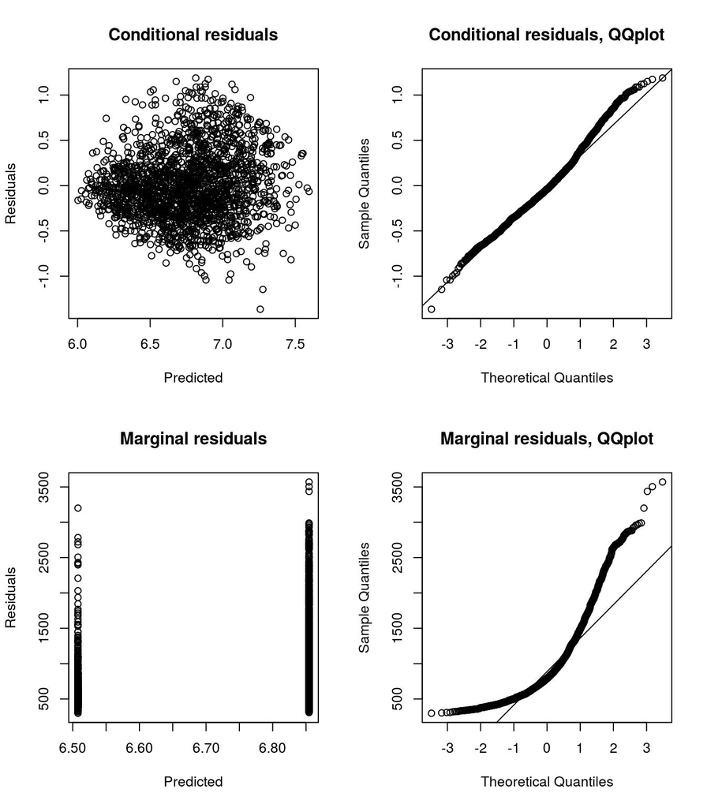

The joint qqplot looks normal. The marginal looks less nice.

## p-values

Although controversial we report the Anova of type III with Satterwhite approximation:

```r
require(lmerTest)
anova(lmm)
```

```
Analysis of Variance Table of type III  with  Satterthwaite
approximation for degrees of freedom
     Sum Sq Mean Sq NumDF DenDF F.value  Pr(>F)
Lang   5.84    5.84     1   143      38 6.9e-09 ***
---
Signif. codes:  0 '***' 0.001 '**' 0.01 '*' 0.05 '.' 0.1 ' ' 1
```

and the effects with the t test:

```r
summary(lmm, transform="log")
```

```
Linear mixed model fit by maximum likelihood t-tests use Satterthwaite approximations to degrees
  of freedom [lmerMod]
Formula: log(Time) ~ Lang + (1 | List:Subject) + (1 | List:Type:Trial)
   Data: DLM

     AIC      BIC   logLik deviance df.resid
    2286     2314    -1138     2276     1988

Scaled residuals:
   Min     1Q Median     3Q    Max
-3.480 -0.653 -0.098  0.543  3.032

Random effects:
 Groups          Name        Variance Std.Dev.
 List:Subject    (Intercept) 0.0648   0.255
 List:Type:Trial (Intercept) 0.0231   0.152
 Residual                    0.1537   0.392
Number of obs: 1993, groups:  List:Subject, 152; List:Type:Trial, 32

Fixed effects:
            Estimate Std. Error       df t value Pr(>|t|)
(Intercept)   6.8546     0.0371  80.5000  184.87  < 2e-16 ***
LangL1       -0.3467     0.0563 142.7000   -6.16  6.9e-09 ***
---
Signif. codes:  0 '***' 0.001 '**' 0.01 '*' 0.05 '.' 0.1 ' ' 1

Correlation of Fixed Effects:
       (Intr)
LangL1 -0.317
```

We also include the analysis via `merTools` package that calculates simulated values of the (fixed and random) effects from the posterior using the function `arm::sim`:

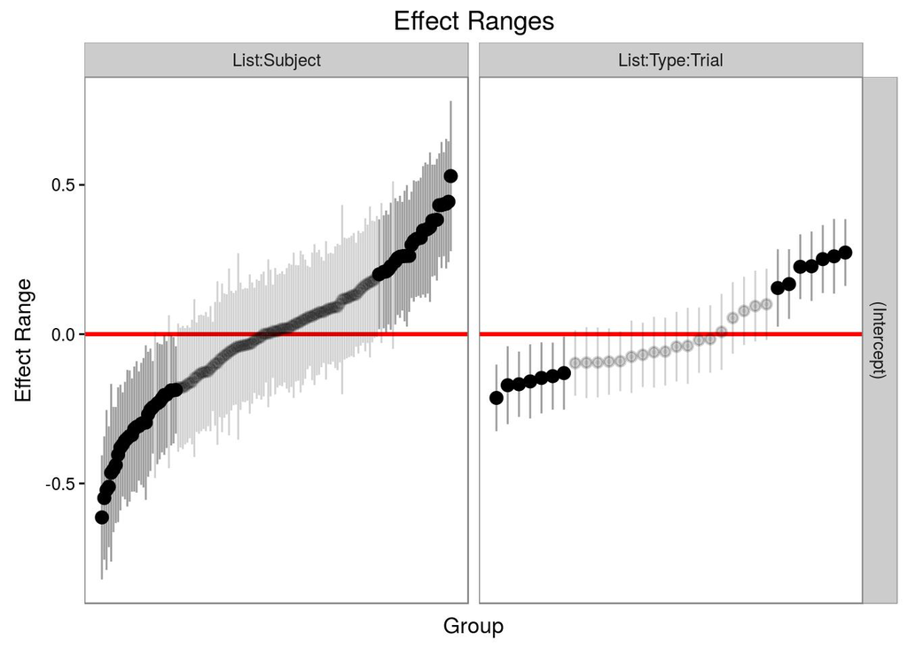

```r
detach("package:lmerTest",unload=TRUE)
require(merTools)
lmm <- lmer(formula = log(Time) ~ Lang + (1 | List:Subject) +
    (1 | List:Type:Trial), data = DLM, REML = FALSE)
plotREsim(REsim(lmm, n.sims= 100), level=0.95, stat="mean")
```

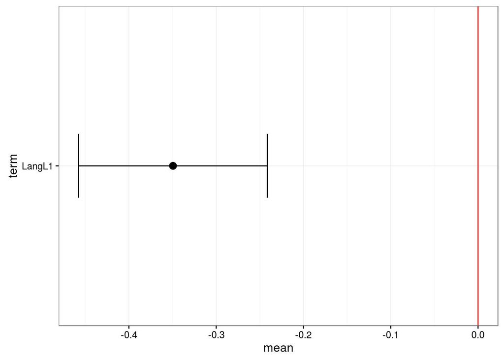

```r
plotFEsim(FEsim(lmm, n.sims = 100), level = 0.95, stat = 'mean', intercept = FALSE)
```

## Conclusions

We plot the random and the fixed effects together with their 95% confidence levels in the Figure. The confidence levels are obtained by the estimated standard deviation and the normal distribution. However, other analysis with boostrapped confidence intervals confirmed the same conclusions.

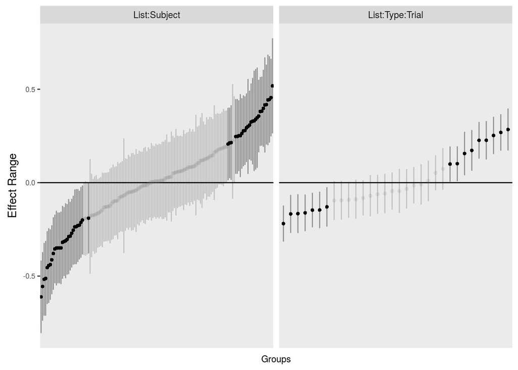

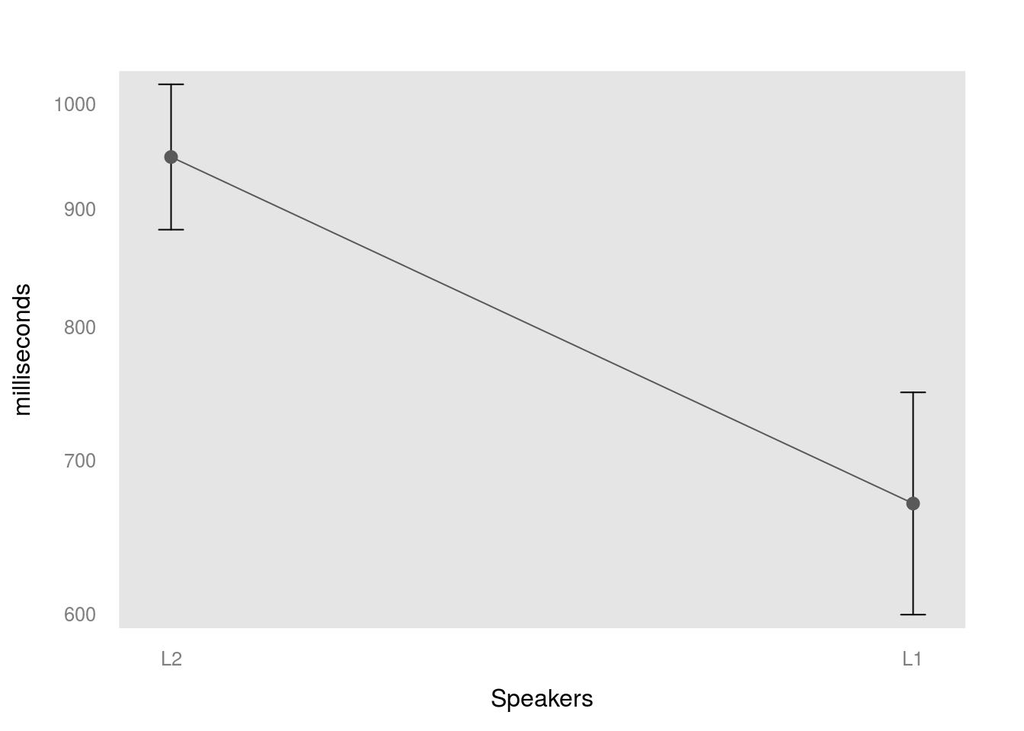

From the figure we can observe that the random effects cause often a significant effect by shifting the intercept by a quantity larger than zero. For the fixed effects we transformed back the effects in the linear time scale of milliseconds. It is evident that L1 speakers have a shorter reaction time and that the Type does not have a significant impact.